# Predict Bike Sharing Demand with AutoGluon Template

## Project: Predict Bike Sharing Demand with AutoGluon

This notebook is a template with each step that you need to complete for the project.

Please fill in your code where there are explicit `?` markers in the notebook. You are welcome to add more cells and code as you see fit.

Once you have completed all the code implementations, please export your notebook as a HTML file so the reviews can view your code. Make sure you have all outputs correctly outputted.

`File-> Export Notebook As... -> Export Notebook as HTML`

There is a writeup to complete as well after all code implememtation is done. Please answer all questions and attach the necessary tables and charts. You can complete the writeup in either markdown or PDF.

Completing the code template and writeup template will cover all of the rubric points for this project.

The rubric contains "Stand Out Suggestions" for enhancing the project beyond the minimum requirements. The stand out suggestions are optional. If you decide to pursue the "stand out suggestions", you can include the code in this notebook and also discuss the results in the writeup file.

## Step 1: Create an account with Kaggle

### Create Kaggle Account and download API key

Below is example of steps to get the API username and key. Each student will have their own username and key.

1. Open account settings.

2. Scroll down to API and click Create New API Token.

3. Open up `kaggle.json` and use the username and key.


## Step 2: Download the Kaggle dataset using the kaggle python library

### Open up Sagemaker Studio and use starter template

1. Notebook should be using a `ml.t3.medium` instance (2 vCPU + 4 GiB)
2. Notebook should be using kernal: `Python 3 (MXNet 1.8 Python 3.7 CPU Optimized)`

### Install packages

```python
#!pip install -U pip
#!pip install -U setuptools wheel
#!pip install -U "mxnet<2.0.0" bokeh==2.0.1
#!pip install autogluon --no-cache-dir
# Without --no-cache-dir, smaller aws instances may have trouble installing
```

### Setup Kaggle API Key

```python
# create the .kaggle directory and an empty kaggle.json file
#!mkdir -p /root/.kaggle
#!touch /root/.kaggle/kaggle.json
#!chmod 600 /root/.kaggle/kaggle.json
```

```python
# Fill in your user name and key from creating the kaggle account and API token file
#import json
#kaggle_username = "FILL_IN_USERNAME"
#kaggle_key = "FILL_IN_KEY"

# Save API token the kaggle.json file
#with open("/root/.kaggle/kaggle.json", "w") as f:
#    f.write(json.dumps({"username": kaggle_username, "key": kaggle_key}))
```

### Download and explore dataset

### Go to the bike sharing demand competition and agree to the terms

```python
# Download the dataset, it will be in a .zip file so you'll need to unzip it as well.
#!kaggle competitions download -c bike-sharing-demand
# If you already downloaded it you can use the -o command to overwrite the file
#!unzip -o bike-sharing-demand.zip
```

```python
import pandas as pd
from autogluon.tabular import TabularPredictor
```

```python
# Create the train dataset in pandas by reading the csv
# Set the parsing of the datetime column so you can use some of the `dt` features in pandas later
train = pd.read_csv('train.csv', parse_dates=['datetime'])
train.head()
```

|  | datetime | season | holiday | workingday | weather | temp | atemp | humidity | windspeed | casual | registered | count |
| --- | --- | --- | --- | --- | --- | --- | --- | --- | --- | --- | --- | --- |
| 0 | 2011-01-01 00:00:00 | 1 | 0 | 0 | 1 | 9.84 | 14.395 | 81 | 0.0 | 3 | 13 | 16 |
| 1 | 2011-01-01 01:00:00 | 1 | 0 | 0 | 1 | 9.02 | 13.635 | 80 | 0.0 | 8 | 32 | 40 |
| 2 | 2011-01-01 02:00:00 | 1 | 0 | 0 | 1 | 9.02 | 13.635 | 80 | 0.0 | 5 | 27 | 32 |
| 3 | 2011-01-01 03:00:00 | 1 | 0 | 0 | 1 | 9.84 | 14.395 | 75 | 0.0 | 3 | 10 | 13 |
| 4 | 2011-01-01 04:00:00 | 1 | 0 | 0 | 1 | 9.84 | 14.395 | 75 | 0.0 | 0 | 1 | 1 |

```python
# Simple output of the train dataset to view some of the min/max/varition of the dataset features.
train.describe()
```

|  | season | holiday | workingday | weather | temp | atemp | humidity | windspeed | casual | registered | count |
| --- | --- | --- | --- | --- | --- | --- | --- | --- | --- | --- | --- |
| count | 10886.000000 | 10886.000000 | 10886.000000 | 10886.000000 | 10886.00000 | 10886.000000 | 10886.000000 | 10886.000000 | 10886.000000 | 10886.000000 | 10886.000000 |
| mean | 2.506614 | 0.028569 | 0.680875 | 1.418427 | 20.23086 | 23.655084 | 61.886460 | 12.799395 | 36.021955 | 155.552177 | 191.574132 |
| std | 1.116174 | 0.166599 | 0.466159 | 0.633839 | 7.79159 | 8.474601 | 19.245033 | 8.164537 | 49.960477 | 151.039033 | 181.144454 |
| min | 1.000000 | 0.000000 | 0.000000 | 1.000000 | 0.82000 | 0.760000 | 0.000000 | 0.000000 | 0.000000 | 0.000000 | 1.000000 |
| 25% | 2.000000 | 0.000000 | 0.000000 | 1.000000 | 13.94000 | 16.665000 | 47.000000 | 7.001500 | 4.000000 | 36.000000 | 42.000000 |
| 50% | 3.000000 | 0.000000 | 1.000000 | 1.000000 | 20.50000 | 24.240000 | 62.000000 | 12.998000 | 17.000000 | 118.000000 | 145.000000 |
| 75% | 4.000000 | 0.000000 | 1.000000 | 2.000000 | 26.24000 | 31.060000 | 77.000000 | 16.997900 | 49.000000 | 222.000000 | 284.000000 |
| max | 4.000000 | 1.000000 | 1.000000 | 4.000000 | 41.00000 | 45.455000 | 100.000000 | 56.996900 | 367.000000 | 886.000000 | 977.000000 |

```python
train.info()
```

```
<class 'pandas.core.frame.DataFrame'>
RangeIndex: 10886 entries, 0 to 10885
Data columns (total 12 columns):
 #   Column      Non-Null Count  Dtype
---  ------      --------------  -----
 0   datetime    10886 non-null  datetime64[ns]
 1   season      10886 non-null  int64
 2   holiday     10886 non-null  int64
 3   workingday  10886 non-null  int64
 4   weather     10886 non-null  int64
 5   temp        10886 non-null  float64
 6   atemp       10886 non-null  float64
 7   humidity    10886 non-null  int64
 8   windspeed   10886 non-null  float64
 9   casual      10886 non-null  int64
 10  registered  10886 non-null  int64
 11  count       10886 non-null  int64
dtypes: datetime64[ns](1), float64(3), int64(8)
memory usage: 1020.7 KB
```

```python
# Create the test pandas dataframe in pandas by reading the csv, remember to parse the datetime!
test = pd.read_csv('test.csv', parse_dates=['datetime'])
test.head()
```

|  | datetime | season | holiday | workingday | weather | temp | atemp | humidity | windspeed |
| --- | --- | --- | --- | --- | --- | --- | --- | --- | --- |
| 0 | 2011-01-20 00:00:00 | 1 | 0 | 1 | 1 | 10.66 | 11.365 | 56 | 26.0027 |
| 1 | 2011-01-20 01:00:00 | 1 | 0 | 1 | 1 | 10.66 | 13.635 | 56 | 0.0000 |
| 2 | 2011-01-20 02:00:00 | 1 | 0 | 1 | 1 | 10.66 | 13.635 | 56 | 0.0000 |
| 3 | 2011-01-20 03:00:00 | 1 | 0 | 1 | 1 | 10.66 | 12.880 | 56 | 11.0014 |
| 4 | 2011-01-20 04:00:00 | 1 | 0 | 1 | 1 | 10.66 | 12.880 | 56 | 11.0014 |

```python
# Same thing as train and test dataset
submission = pd.read_csv('sampleSubmission.csv', parse_dates=['datetime'])
submission.head()
```

|  | datetime | count |
| --- | --- | --- |
| 0 | 2011-01-20 00:00:00 | 0 |
| 1 | 2011-01-20 01:00:00 | 0 |
| 2 | 2011-01-20 02:00:00 | 0 |
| 3 | 2011-01-20 03:00:00 | 0 |
| 4 | 2011-01-20 04:00:00 | 0 |

## Step 3: Train a model using AutoGluon’s Tabular Prediction

Requirements:

- We are prediting `count`, so it is the label we are setting.
- Ignore `casual` and `registered` columns as they are also not present in the test dataset.
- Use the `root_mean_squared_error` as the metric to use for evaluation.
- Set a time limit of 10 minutes (600 seconds).
- Use the preset `best_quality` to focus on creating the best model.

```python
predictor = TabularPredictor(
    label="count",
    eval_metric = 'root_mean_squared_error',
    verbosity=0,
    learner_kwargs={"ignored_columns": ["casual", "registered"]}
).fit(
    train_data=train,
    time_limit=600,
    presets="best_quality"
)
```

### Review AutoGluon's training run with ranking of models that did the best.

```python
predictor.fit_summary()
```

```
*** Summary of fit() ***
Estimated performance of each model:
                     model   score_val  pred_time_val    fit_time  pred_time_val_marginal  fit_time_marginal  stack_level  can_infer  fit_order
0      WeightedEnsemble_L3 -114.471103       4.734066  562.794764                0.000469           0.333734            3       True         22
1   NeuralNetFastAI_BAG_L2 -115.008580       3.015070  442.164308                0.233237          79.680950            2       True         18
2        LightGBMXT_BAG_L2 -115.872987       2.832541  366.424783                0.050708           3.941425            2       True         13
3          CatBoost_BAG_L2 -116.482570       2.811970  373.469159                0.030137          10.985801            2       True         16
4          LightGBM_BAG_L2 -116.978851       2.814542  365.298281                0.032709           2.814923            2       True         14
5           XGBoost_BAG_L2 -117.503005       2.825603  367.515157                0.043770           5.031799            2       True         19
6     ExtraTreesMSE_BAG_L2 -117.685323       3.178213  363.922733                0.396380           1.439375            2       True         17
7     LightGBMLarge_BAG_L2 -118.240102       2.819249  366.308295                0.037416           3.824937            2       True         21
8      WeightedEnsemble_L2 -118.394069       1.447442  198.734773                0.000398           0.389450            2       True         12
9   RandomForestMSE_BAG_L1 -118.456660       0.322682    1.569566                0.322682           1.569566            1       True          5
10   NeuralNetMXNet_BAG_L2 -119.055231       4.020563  474.584357                1.238730         112.100999            2       True         20
11  RandomForestMSE_BAG_L2 -119.379416       3.176231  367.357997                0.394398           4.874639            2       True         15
12    ExtraTreesMSE_BAG_L1 -128.733445       0.326615    0.825068                0.326615           0.825068            1       True          7
13    LightGBMLarge_BAG_L1 -130.731697       0.075354    9.827688                0.075354           9.827688            1       True         11
14         LightGBM_BAG_L1 -132.286410       0.089925    6.275786                0.089925           6.275786            1       True          4
15          XGBoost_BAG_L1 -132.308522       0.052306    7.561448                0.052306           7.561448            1       True          9
16         CatBoost_BAG_L1 -132.349692       0.031869   35.713664                0.031869          35.713664            1       True          6
17       LightGBMXT_BAG_L1 -134.088334       0.343669   24.491879                0.343669          24.491879            1       True          3
18  NeuralNetFastAI_BAG_L1 -137.822764       0.197597   79.415890                0.197597          79.415890            1       True          8
19   NeuralNetMXNet_BAG_L1 -141.201355       1.124362  196.775757                1.124362         196.775757            1       True         10
20   KNeighborsUnif_BAG_L1 -160.413078       0.108770    0.013225                0.108770           0.013225            1       True          1
21   KNeighborsDist_BAG_L1 -169.552096       0.108685    0.013387                0.108685           0.013387            1       True          2
Number of models trained: 22
Types of models trained:
{'StackerEnsembleModel_NNFastAiTabular', 'StackerEnsembleModel_XT', 'StackerEnsembleModel_XGBoost', 'StackerEnsembleModel_RF', 'StackerEnsembleModel_KNN', 'StackerEnsembleModel_CatBoost', 'StackerEnsembleModel_LGB', 'WeightedEnsembleModel', 'StackerEnsembleModel_TabularNeuralNet'}
Bagging used: True  (with 10 folds)
Multi-layer stack-ensembling used: True  (with 3 levels)
Feature Metadata (Processed):
(raw dtype, special dtypes):
('float', [])                : 3 | ['temp', 'atemp', 'windspeed']
('int', [])                  : 3 | ['season', 'weather', 'humidity']
('int', ['bool'])            : 2 | ['holiday', 'workingday']
('int', ['datetime_as_int']) : 1 | ['datetime']
*** End of fit() summary ***
```

[output not shown]

[output cut: 223 more lines]

[output not shown]

### Create predictions from test dataset

```python
predictions = predictor.predict(test)
predictions.head()
```

```
0     92.535690
1     90.022308
2     90.023666
3    101.299156
4    101.252235
Name: count, dtype: float32
```

#### NOTE: Kaggle will reject the submission if we don't set everything to be > 0.

```python
# Describe the `predictions` series to see if there are any negative values
predictions.describe()
```

```
count    6493.000000
mean      210.509857
std       130.377350
min       -15.205791
25%       103.844917
50%       193.342621
75%       299.739929
max       661.707031
Name: count, dtype: float64
```

```python
# How many negative values do we have?
predictions.lt(0).sum().sum()
```

```
3
```

```python
predictions.describe()
```

```
count    6493.000000
mean      210.509857
std       130.377350
min       -15.205791
25%       103.844917
50%       193.342621
75%       299.739929
max       661.707031
Name: count, dtype: float64
```

```python
predictions.tail()
```

```
6488    314.295471
6489    314.299683
6490    312.583252
6491    311.247284
6492    333.316132
Name: count, dtype: float32
```

```python
# Set them to zero
predictions = predictions.clip(lower=0)
```

### Set predictions to submission dataframe, save, and submit

```python
submission["count"] = predictions
# Round count column values
submission['count'] = submission['count'].apply(lambda x: round(x))
submission.to_csv("submission.csv", index=False)
```

```python
!kaggle competitions submit -c bike-sharing-demand -f submission.csv -m "first raw submission"
```

```
Successfully submitted to Bike Sharing Demand
```

#### View submission via the command line or in the web browser under the competition's page - `My Submissions`

```python
!kaggle competitions submissions -c bike-sharing-demand | tail -n +1 | head -n 15
```

```
fileName                     date                 description                        status    publicScore  privateScore
---------------------------  -------------------  ---------------------------------  --------  -----------  ------------
submission.csv               2022-02-13 10:10:11  first raw submission               complete  1.38713      1.38713
submission_new_hpo.csv       2022-02-12 18:57:21  new features with hyperparameters  complete  0.77948      0.77948
submission_new_features.csv  2022-02-12 18:50:33  new features                       complete  0.80946      0.80946
submission.csv               2022-02-12 18:34:57  first raw submission               complete  1.38920      1.38920
submission_new_hpo.csv       2022-02-12 16:06:13  new features with hyperparameters  complete  0.79364      0.79364
submission_new_features.csv  2022-02-12 15:55:33  new features                       complete  0.79572      0.79572
submission.csv               2022-02-12 15:45:14  first raw submission               complete  4.76188      4.76188
submission.csv               2022-02-12 15:08:06  first raw submission               complete  4.76188      4.76188
submission_new_hpo.csv       2022-02-12 14:07:50  new features with hyperparameters  complete  0.80874      0.80874
submission_new_hpo.csv       2022-02-12 13:20:41  new features with hyperparameters  complete  0.78784      0.78784
submission_new_hpo.csv       2022-02-12 12:15:09  new features with hyperparameters  complete  0.87694      0.87694
submission_new_hpo.csv       2022-02-12 10:48:29  new features with hyperparameters  complete  0.72500      0.72500
submission_new_hpo.csv       2022-02-12 10:17:47  new features with hyperparameters  complete  0.81992      0.81992
```

#### Initial score of `1.38713`

## Step 4: Exploratory Data Analysis and Creating an additional feature

- Any additional feature will do, but a great suggestion would be to separate out the datetime into hour, day, or month parts.

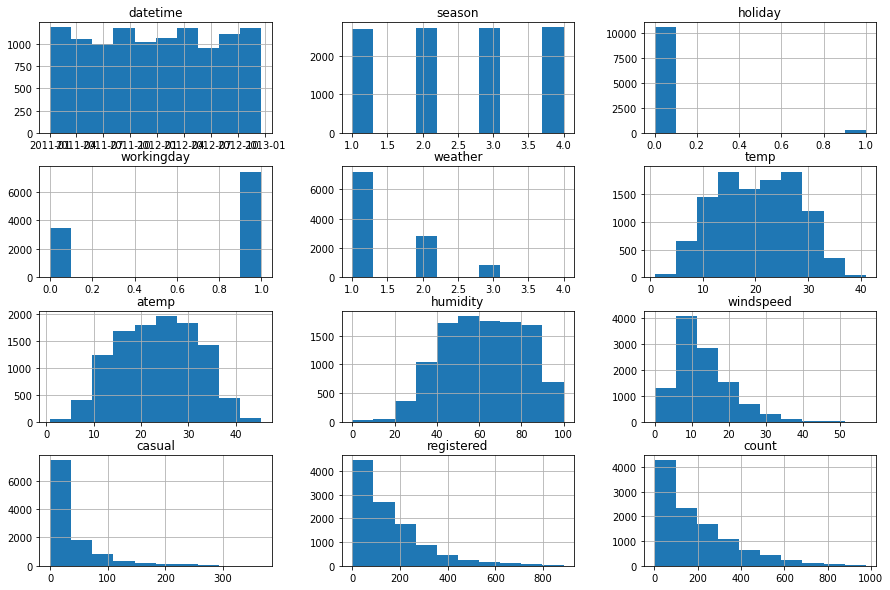

```python
# Create a histogram of all features to show the distribution of each one relative to the data. This is part of the exploritory data analysis
train.hist(figsize = (15,10));
```

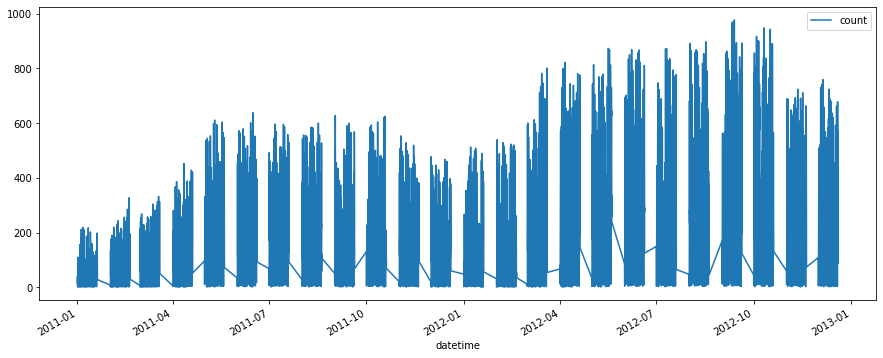

```python
# time series plot for demand
train.plot(x='datetime', y='count', figsize=(15, 6));
```

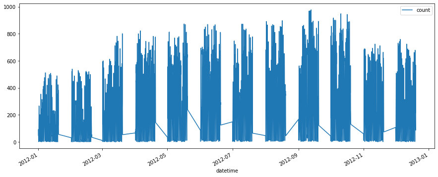

```python
# time series plot for demand for a particular year
train.loc[train.datetime.dt.year == 2012].plot(x='datetime', y='count', figsize=(15, 6));
```

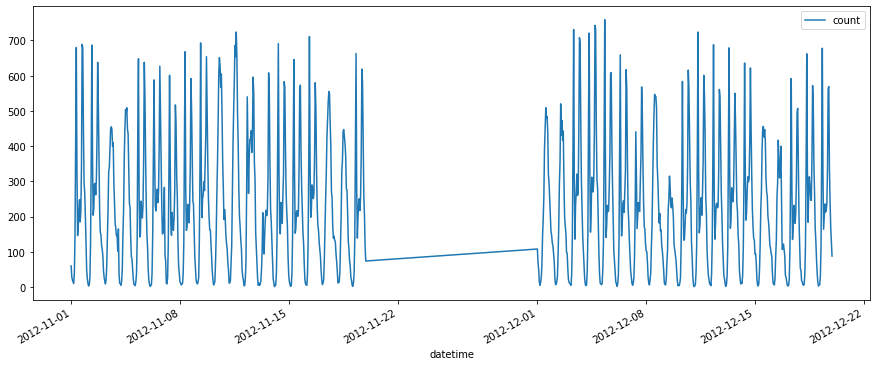

```python
# time series plot for two consecutive months
train.loc[(train.datetime.dt.year == 2012) & ((train.datetime.dt.month == 11) | (train.datetime.dt.month == 12))].plot(x='datetime', y='count', figsize=(15, 6));
```

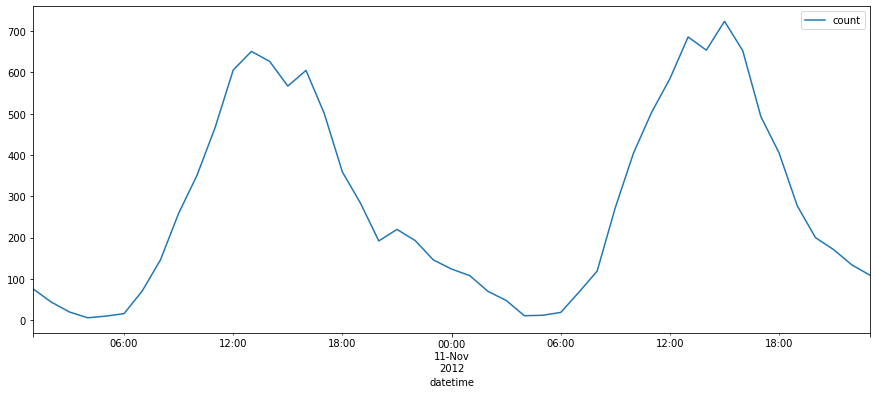

```python
# time series plot for a particular weekend
train.loc[(train.datetime > '2012-11-10') & (train.datetime < '2012-11-12')].plot(x='datetime', y='count', figsize=(15, 6));
```

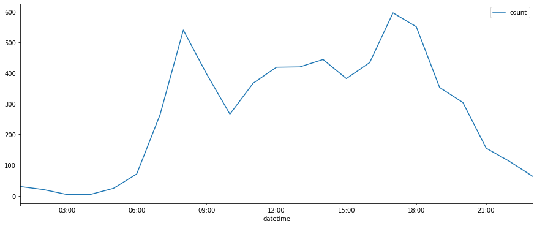

```python
# time series plot for a particular weekday: Monday
train.loc[(train.datetime > '2012-11-12') & (train.datetime < '2012-11-13')].plot(x='datetime', y='count', figsize=(15, 6));
```

```python
# Seperate hour, day, month from datetime
train['hour'] = train['datetime'].dt.hour
train['day'] = train['datetime'].dt.day
train['month'] = train['datetime'].dt.month
test['hour'] = test['datetime'].dt.hour
test['day'] = test['datetime'].dt.day
test['month'] = test['datetime'].dt.month
```

```python
# create a new feature: time_of_day
def get_time_of_day(x):
    if (x > 4) and (x <= 8):
        return 0 # Early Morning
    elif (x > 8) and (x <= 12 ):
        return 1 # Morning
    elif (x > 12) and (x <= 16):
        return 2 # Noon
    elif (x > 16) and (x <= 20) :
        return 3 # Evening
    elif (x > 20) and (x <= 24):
        return 4 # Night
    elif (x <= 4):
        return 5 # Late Night


train['time_of_day'] = train['hour'].apply(get_time_of_day)
test['time_of_day'] = test['hour'].apply(get_time_of_day)
```

```python
# create a new feature: temp_category
def get_temp_category(x):
    if x <= 10:
        return 0 # low temp
    elif (x > 10) and (x <= 25 ):
        return 1 # mild temp
    elif (x > 25):
        return 2 # hot temp


train['temp_category'] = train['temp'].apply(get_temp_category)
test['temp_category'] = test['temp'].apply(get_temp_category)
```

```python
# create a new feature: wind_category
def get_wind_category(x):
    if x <= 15:
        return 0 # normal wind
    elif (x > 10):
        return 1 # high wind


train['wind_category'] = train['windspeed'].apply(get_wind_category)
test['wind_category'] = test['windspeed'].apply(get_wind_category)
```

```python
# create a new feature: humid_category
def get_humid_category(x):
    if x <= 30:
        return 0 # low humidity
    elif (x > 30) and (x <= 50 ):
        return 1 # normal humidity
    elif (x > 50):
        return 2 # high humidity

train['humid_category'] = train['humidity'].apply(get_humid_category)
test['humid_category'] = test['humidity'].apply(get_humid_category)
```

```python
# create a new feature: atemp_category
def get_atemp_category(x):
    if x <= 10:
        return 0 # low temp
    elif (x > 10) and (x <= 25 ):
        return 1 # mild temp
    elif (x > 25):
        return 2 # hot temp


train['atemp_category'] = train['atemp'].apply(get_atemp_category)
test['atemp_category'] = test['atemp'].apply(get_atemp_category)
```

```python
train.drop(['datetime', 'temp', 'windspeed', 'humidity', 'atemp'], axis=1, inplace=True)
test.drop(['datetime', 'temp', 'windspeed', 'humidity', 'atemp'], axis=1, inplace=True)
```

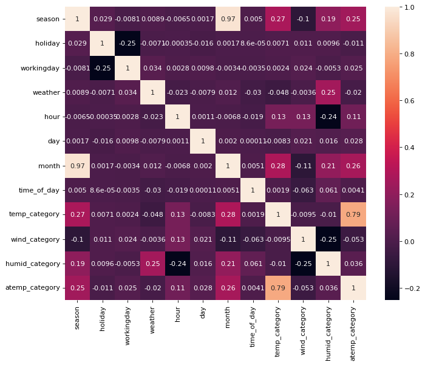

```python
import seaborn as sn
import matplotlib.pyplot as plt

plt.figure(figsize=(10, 8), dpi=80)

sn.heatmap(train.drop(['count', 'registered','casual'], axis=1).corr(), annot=True)
plt.show()
```

```python
# removing season column as it's having very high correlation with month
train.drop(['season'], axis=1, inplace=True)
test.drop(['season'], axis=1, inplace=True)
```